# Ch2 Getting started with ggplot2

### Exercises

1. What’s the problem with the plot created by `ggplot(mpg, aes(cty, hwy)) + geom_point()`? Which of the geoms described above is most effective at remedying the problem?
2. One challenge with `ggplot(mpg, aes(class, hwy)) + geom_boxplot()` is that the ordering of `class` is alphabetical, which is not terribly useful. How could you change the factor levels to be more informative?

   Rather than reordering the factor by hand, you can do it automatically based on the data: `ggplot(mpg, aes(reorder(class, hwy), hwy)) + geom_boxplot()`. What does `reorder()` do? Read the documentation.
3. Explore the distribution of the carat variable in the `diamonds` dataset. What binwidth reveals the most interesting patterns?
4. Explore the distribution of the price variable in the `diamonds` data. How does the distribution vary by cut?
5. You now know (at least) three ways to compare the distributions of subgroups: `geom_violin()`, `geom_freqpoly()` and the colour aesthetic, or `geom_histogram()` and facetting. What are the strengths and weaknesses of each approach? What other approaches could you try?
6. Read the documentation for `geom_bar()`. What does the `weight` aesthetic do?
7. Using the techniques already discussed in this chapter, come up with three ways to visualise a 2d categorical distribution. Try them out by visualising the distribution of `model` and `manufacturer`, `trans` and `class`, and `cyl` and `trans`.

## Modifying the axes

You’ll learn the full range of options available in scales, but two families of useful helpers let you make the most common modifications. `xlab()` and `ylab()` modify the x- and y-axis labels:

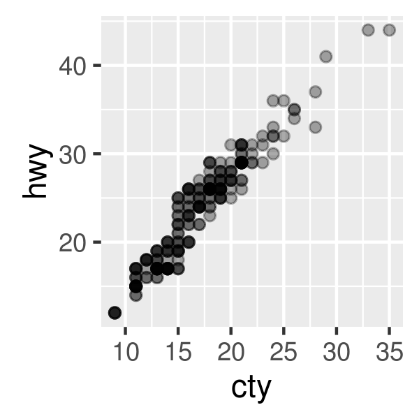

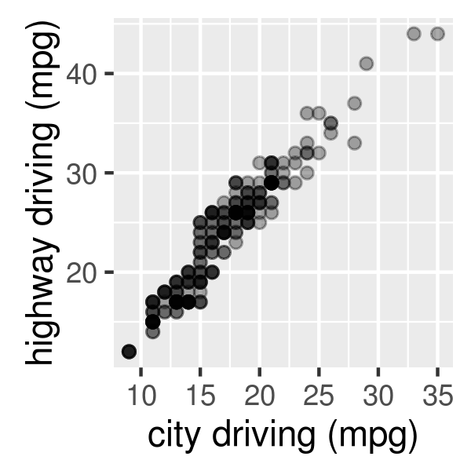

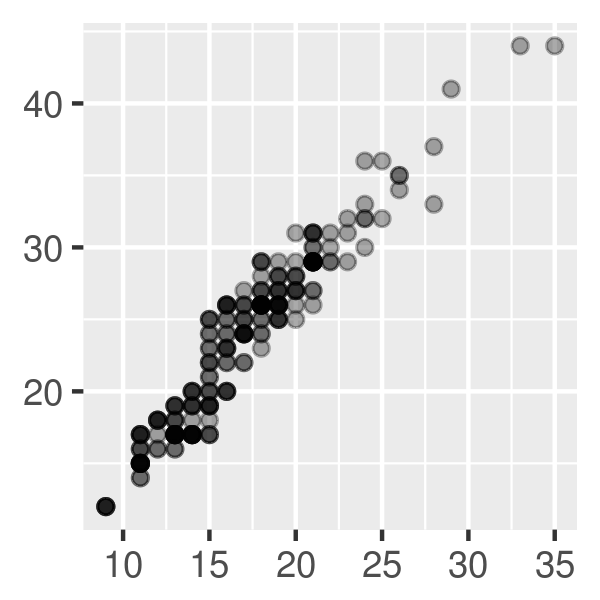

```r
ggplot(mpg, aes(cty, hwy)) +
  geom_point(alpha = 1 / 3)

ggplot(mpg, aes(cty, hwy)) +
  geom_point(alpha = 1 / 3) +
  xlab("city driving (mpg)") +
  ylab("highway driving (mpg)")

# Remove the axis labels with NULL
ggplot(mpg, aes(cty, hwy)) +
  geom_point(alpha = 1 / 3) +
  xlab(NULL) +
  ylab(NULL)
```

`xlim()` and `ylim()` modify the limits of axes:

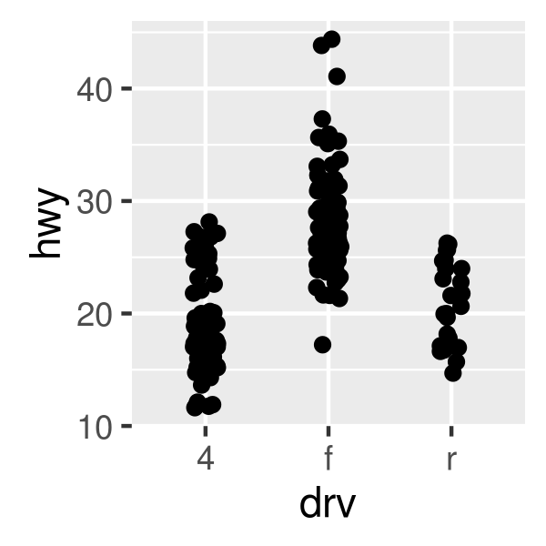

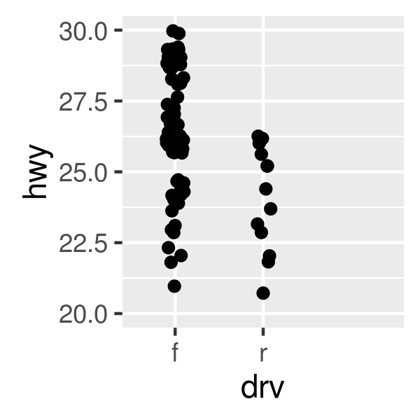

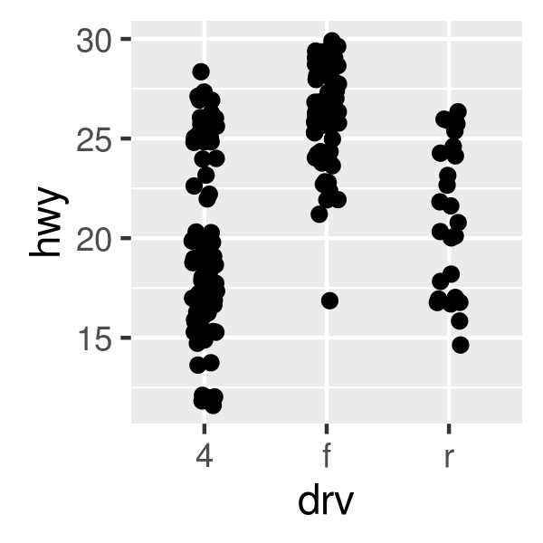

```r
ggplot(mpg, aes(drv, hwy)) +
  geom_jitter(width = 0.25)

ggplot(mpg, aes(drv, hwy)) +
  geom_jitter(width = 0.25) +
  xlim("f", "r") +
  ylim(20, 30)
# For continuous scales, use NA to set only one limit
ggplot(mpg, aes(drv, hwy)) +
  geom_jitter(width = 0.25, na.rm = TRUE) +
  ylim(NA, 30)
```

Changing the axes limits sets values outside the range to `NA`. You can suppress the associated warning with `na.rm = TRUE`.

## Output

Most of the time you create a plot object and immediately plot it, but you can also save a plot to a variable and manipulate it:

```r
p <- ggplot(mpg, aes(displ, hwy, colour = factor(cyl))) +
  geom_point()
```

Once you have a plot object, there are a few things you can do with it:

- Render it on screen with `print()`. This happens automatically when running interactively, but inside a loop or function, you’ll need to `print()` it yourself.

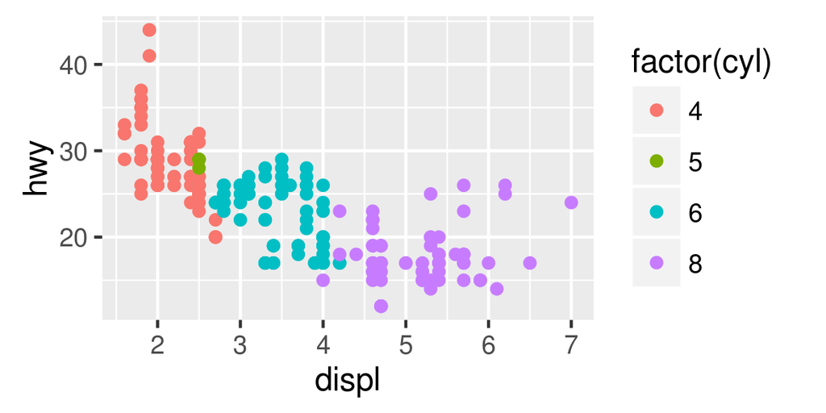

  ```r
  print(p)
  ```

- Save it to disk with `ggsave()`, described in saving your output.

  ```r
  # Save png to disk
  ggsave("plot.png", width = 5, height = 5)
  ```

- Briefly describe its structure with `summary()`.

  ```r
  summary(p)
  ```

  ```
  #> data: manufacturer, model, displ, year, cyl, trans, drv, cty, hwy,
  #>   fl, class [234x11]
  #> mapping:  x = displ, y = hwy, colour = factor(cyl)
  #> faceting: facet_null()
  #> -----------------------------------
  #> geom_point: na.rm = FALSE
  #> stat_identity: na.rm = FALSE
  #> position_identity
  ```

- Save a cached copy of it to disk, with `saveRDS()`. This saves a complete copy of the plot object, so you can easily re-create it with `readRDS()`.

  ```r
  saveRDS(p, "plot.rds")
  q <- readRDS("plot.rds")
  ```

You’ll learn more about how to manipulate these objects in programming with ggplot2.

## Quick plots

In some cases, you will want to create a quick plot with a minimum of typing. In these cases you may prefer to use `qplot()` over `ggplot()`. `qplot()` lets you define a plot in a single call, picking a geom by default if you don’t supply one. To use it, provide a set of aesthetics and a data set:

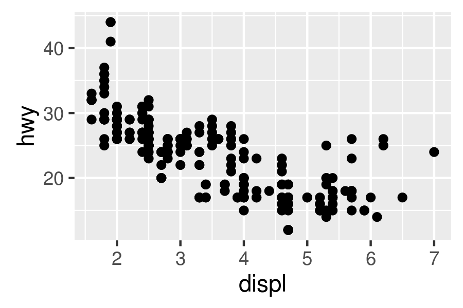

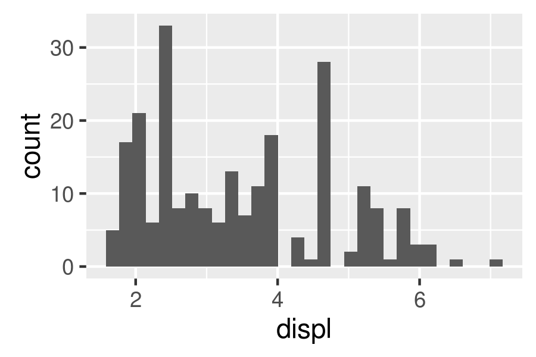

```r
qplot(displ, hwy, data = mpg)
qplot(displ, data = mpg)
```

Unless otherwise specified, `qplot()` tries to pick a sensible geometry and statistic based on the arguments provided. For example, if you give `qplot()` `x` and `y` variables, it’ll create a scatterplot. If you just give it an `x`, it’ll create a histogram or bar chart depending on the type of variable.

`qplot()` assumes that all variables should be scaled by default. If you want to set an aesthetic to a constant, you need to use `I()`:

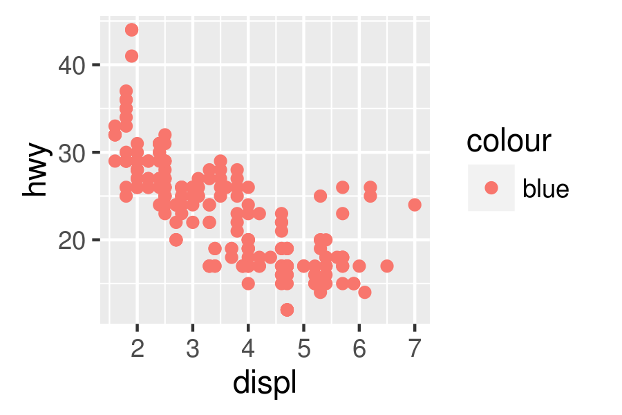

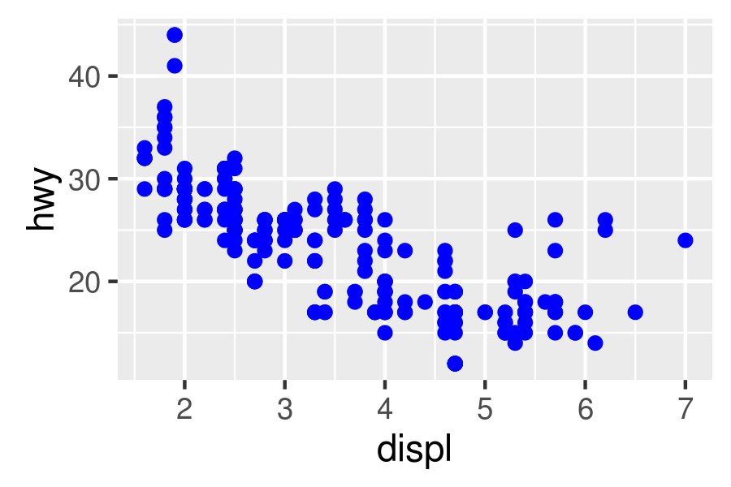

```r
qplot(displ, hwy, data = mpg, colour = "blue")
qplot(displ, hwy, data = mpg, colour = I("blue"))
```

If you’re used to `plot()` you may find `qplot()` to be a useful crutch to get up and running quickly. However, while it’s possible to use `qplot()` to access all of the customizability of ggplot2, I don’t recommend it. If you find yourself making a more complex graph, e.g. using different aesthetics in different layers or manually setting visual properties, use `ggplot()`, not `qplot()`.